# MTH6139 Time Series

Coursework 1 – Time Series Analysis and Forecasting of Nottingham Air Temperatures

Arushi Gupta

Spring term 2025

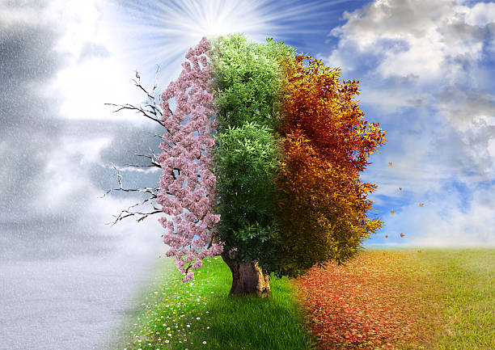

# Section 1: Introduction📝

Weather patterns fluctuate throughout time, and historical temperatures can help us understand why. In this project, we will examine monthly air temperature data to look for trends and seasonal patterns. We’ll assess the data with visualisations, linear regression, and Prophet forecasting to try to anticipate future temperatures. The goal is to make sense of the data and assess how well various forecasting methods work.

Dataset Source: Anderson, O. D. (1976) Time Series Analysis and Forecasting: The Box-Jenkins approach. Butterworths. Series R.

## 1.1 What does ‘nottem’ mean?🌡️

The nottem dataset contains 240 observations of monthly average air temperatures (in degrees Fahrenheit) recorded in Nottingham, UK, between January 1920 and December 1939. As a time series dataset, each data point is collected at regular monthly intervals, making it well-suited for analysing trends over time. I chose this dataset because it clearly demonstrates seasonality in time series data, making it ideal for testing forecasting systems. Source:Anderson, O. D. (1976) Time Series Analysis and Forecasting: The Box-Jenkins approach. Butterworths. Series R.

## 1.2 Purpose of the Project 🎯

-**Understand historical temperature changes** : Look at how Nottingham’s monthly air temperatures shifted over 20 years and see if there were any noticeable trends or unusual patterns.  
-**Identify seasonal patterns** : Explore whether temperatures followed a regular cycle each year, with predictable warm summers and cold winters.  
-**Analyse long-term trends with linear regression** : Use a simple statistical model to check if there was a steady increase or decrease in temperature over time.  
-**Predict future temperatures using Prophet** : Apply Prophet, a forecasting tool, to make short-term predictions and see how well it captures seasonal trends.  
-**Visualise the data clearly** : Create charts and graphs to make trends, patterns, and predictions easy to interpret and understand.

# Section 2: Visualisations and Analysis🔎

We will now look at the various plots and analyse them. By examining various plots, we aim to uncover how Nottingham’s air temperature fluctuated over the years and determine whether significant long-term changes are present.

## 2.1 Time Series Plot📈

```r
#Load the libraries we need for this project
library(prophet)  # Prophet is a forecasting model for time series.
library(zoo)  # This helps with managing time series data, especially for handling dates and formatting them correctly.
```

```r
# Convert the 'nottem' dataset into a data frame so it's easier to work with
nottem.df = data.frame(
    ds = zoo::as.yearmon(time(nottem)),  # Turn the time index into a year-month format (YYYY-MM)
    y = nottem  # Store the temperature values in a column called 'y'
)

# Fit the Prophet model to the dataset
temp_model = prophet::prophet(nottem.df)  # Train the model using our historical temperature data
```

```
## Disabling weekly seasonality. Run prophet with weekly.seasonality=TRUE to override this.
```

```
## Disabling daily seasonality. Run prophet with daily.seasonality=TRUE to override this.
```

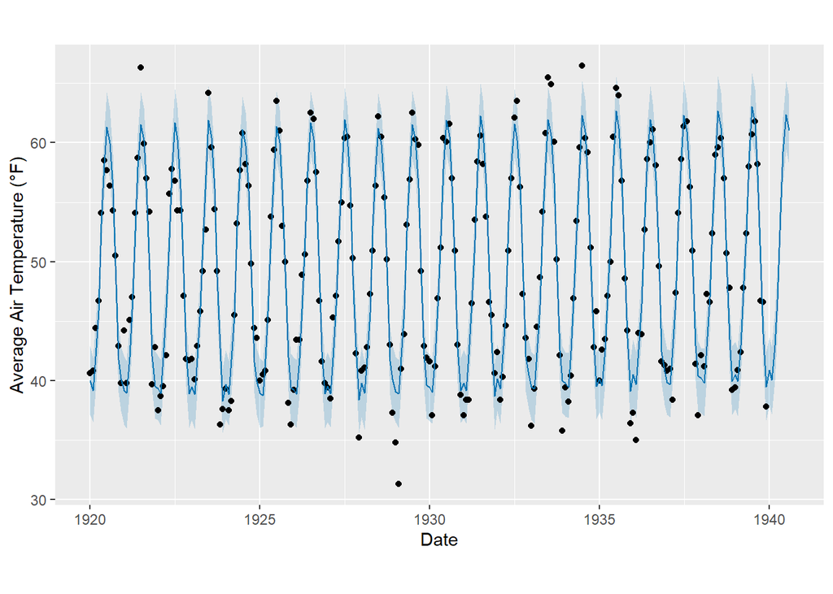

```r
# Create a set of future dates for the model to predict
future_dates = prophet::make_future_dataframe(temp_model, periods=8, freq="month")
# 'periods=8' means we're forecasting 8 months into the future
# 'freq="month"' so we get monthly predictions

# Generate predictions for the future dates
forecast = predict(temp_model, future_dates)
# Prophet will use patterns from the historical data to estimate future temperatures

# Plot the forecasted temperatures
plot(temp_model, forecast,
     main = "Monthly Average Air Temperatures in Nottingham",  # Title of the graph
     xlab = "Date",  # Label for the x-axis (time)
     ylab = "Average Air Temperature (°F)")  # Label for the y-axis (temperature)
```

**Understanding the Plot:**

This plot visualises the monthly average air temperature in Nottingham between 1920 and 1939. It helps us identify trends, seasonal changes, and how well the Prophet model captures these patterns.

- **⚫ Black dots** → Represent the actual recorded temperatures.
- **🔵 Blue line** → Shows the model’s predicted trend, highlighting temperature fluctuations over time.
- **🔹 Shaded area around the blue line** → Represents the model’s confidence range, indicating uncertainty in its predictions.

**Key Findings:**

**1.Clear Seasonality** Temperatures rise in summer and drop in winter, following a consistent yearly cycle. The sharp peaks and dips confirm a strong seasonal pattern, repeating every year.

**2.No Major Long-Term Trend** The highest and lowest temperatures remain fairly stable over the years. There’s no clear evidence of long-term warming or cooling, suggesting Nottingham’s climate was steady during this period.

## 2.2 Linear Regression Analysis📈

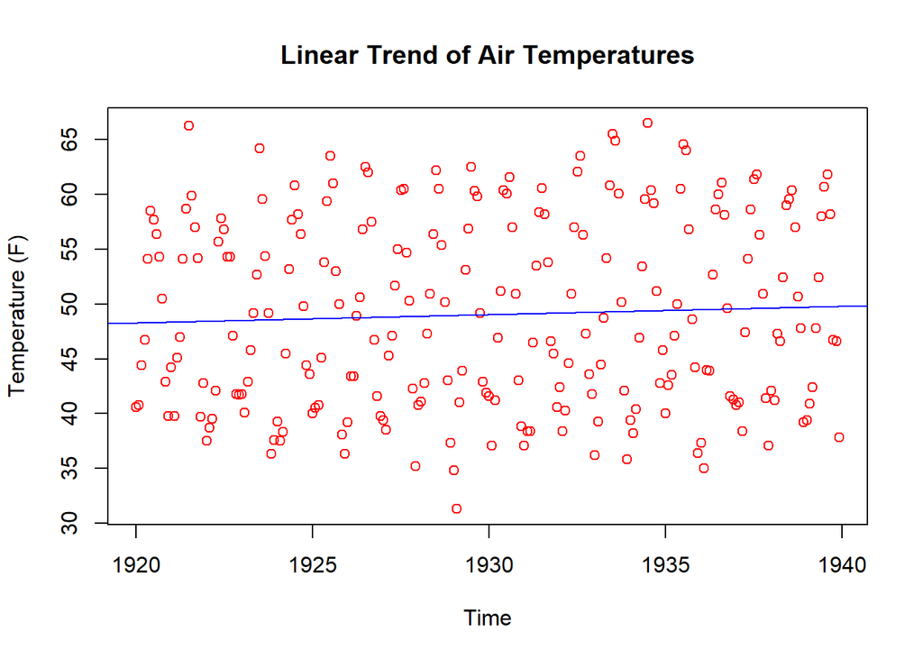

```r
# Create a scatter plot of temperature data over time
plot(nottem, type = "p", col = "red",  # Plots temperature values as red dots
     main = "Linear Trend of Air Temperatures",  # Adds a title to explain what the graph shows
     xlab = "Time",  # Labels the x-axis as "Time" (years from 1920 to 1939)
     ylab = "Temperature (F)")  # Labels the y-axis as "Temperature (Fahrenheit)")

# Fit a linear regression model to check if temperatures are increasing or decreasing
lm_model <- lm(nottem ~ time(nottem))  # Creates a trend line that estimates how temperature changes over time

# Add the trend line to the plot
abline(lm_model, col = "blue")  # Draws a blue line to show the overall temperature trend
```

**Understanding the plot:**

This plot visualises the linear trend of air temperatures in Nottingham from 1920 to 1939. It helps us understand if there is a long-term increase or decrease in temperature and whether any patterns emerge over time.

- **🔴 Red circles** → Represent the actual recorded monthly average temperatures.
- **🔵 Blue line** → Shows the linear regression trend, indicating whether temperatures are rising or falling over the years.

**Key Findings:**

1.**No Clear Long-Term Trend**  
The blue trend line is mostly flat, meaning temperatures didn’t really increase or decrease over the 20-year period. While temperatures go up and down each month, overall, Nottingham’s climate stayed fairly steady with no major warming or cooling.

2.**Big Temperature Swings each month**  
The red circles are spread out quite a bit, showing that temperatures varied a lot from month to month. This suggests that temperature changes were more about natural seasonal shifts rather than any long-term trend.

3.**Seasonal Patterns Matter the Most**  
Since the trend line doesn’t go strongly up or down, it’s clear that the biggest factor affecting temperature changes is the time of year. This matches what we’d expect—temperatures rise in the summer and drop in the winter, following a repeating yearly cycle.

## 2.3 Prophet Component Plots📊

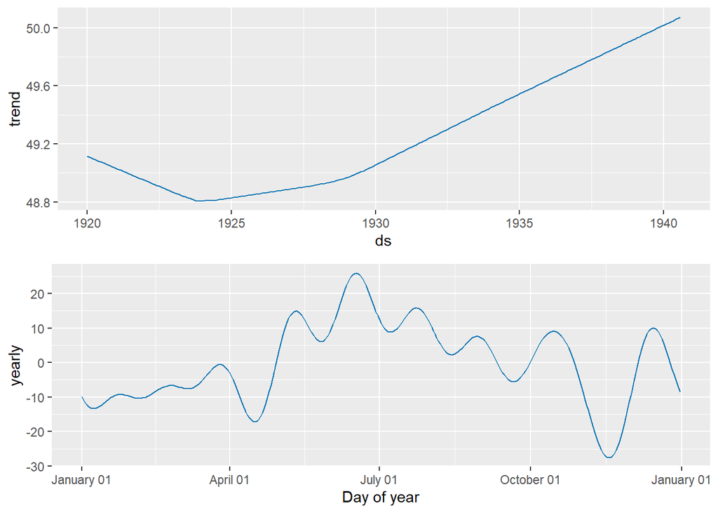

```r
## Generate Prophet component plots to analyse trends and seasonality
prophet::prophet_plot_components(temp_model,forecast)
```

**First plot analysis:**

The x-axis represents time from 1920 to 1940, while the y-axis shows the estimated long-term temperature trend. The plot follows a U-shaped pattern, meaning:

-From 1920 to the mid-1920s, there is a small drop in temperatures.

-From the late 1920s onwards, temperatures gradually increase, suggesting a slight warming trend over time.

What this means: Although seasonal changes have the biggest impact on temperature, there is a small but noticeable long-term increase, especially after 1930. This suggests that Nottingham’s average air temperatures may have been warming slightly over this period.

**Second plot analysis:**

The x-axis represents the months from January to December, while the y-axis shows how temperatures typically change throughout the year.

## 2.4 Residual Plot🎯

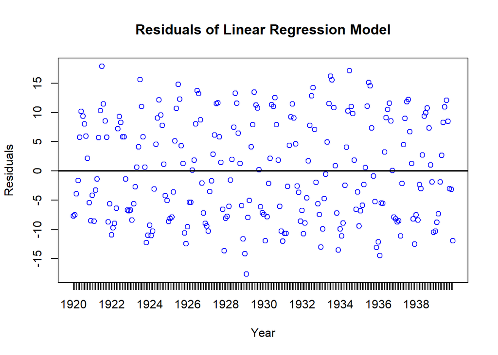

```r
# Create a scatter plot of residuals (errors between actual and predicted values)
plot(nottem.df$ds, residuals(lm_model),  # X-axis: Years, Y-axis: Residual values
     type="p",  # Plot individual points
     col="blue",  # Use blue dots for better visibility
     xlab="Year",  # Label x-axis as "Year"
     ylab="Residuals",  # Label y-axis as "Residuals"
     main="Residuals of Linear Regression Model")  # Add a title to describe the plot

# Add a horizontal line at y=0 to serve as a reference
abline(h=0, col="black", lwd=2)
```

**Plot analysis:**

A residual plot is used to evaluate the fit of a regression model by displaying the difference between actual and predicted values.

1.**Residuals are evenly spread around zero** The points are scattered both above and below the black line at 0, which suggests that the model does not have a strong bias.

3.**Some variability in residuals**  
While most residuals stay within a range of -15 to 15, there is some fluctuation, meaning the model is not perfect but reasonable for capturing the trend.

**We can also use an interactive plot to see both the actual and predicted values. We can also closely analyse certain time frames using this graph. Luckily, the results match what we’ve seen in the earlier analysis, which supports the accuracy of the model.**

```r
# Generates an interactive plot of the forecast using Prophet
dyplot.prophet(temp_model, forecast)
```

[interactive chart not shown]

```r
# Fits the Prophet model
m = prophet::prophet(nottem.df)
```

```
## Disabling weekly seasonality. Run prophet with weekly.seasonality=TRUE to override this.
```

```
## Disabling daily seasonality. Run prophet with daily.seasonality=TRUE to override this.
```

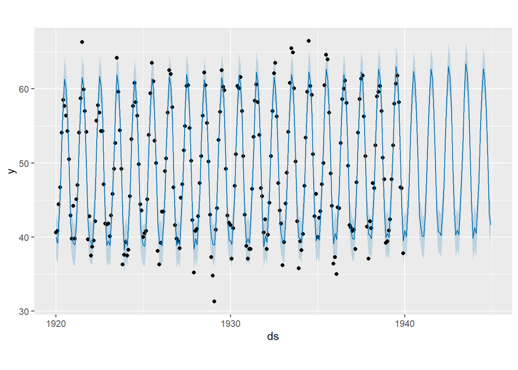

```r
# Creates future dates (60 months/5 years ahead)
f = prophet::make_future_dataframe(m, periods = 60, freq = "month")

# Generates predictions
p = predict(m, f)

# Plots forecast
plot(m, p)
```

**Understanding the plot:**

This plot shows the forecasted air temperatures in Nottingham based on historical data, using Prophet to predict the next 5 years (60 months). It helps us see whether temperature patterns stay consistent over time and how well the model captures seasonal changes and long-term trends.

**Key Findings:**

**1. Temperatures Follow a Strong Seasonal Pattern**  
-The forecast clearly picks up on the repeating yearly temperature cycle, with hotter summers and colder winters.  
-The peaks and dips remain steady, showing that seasonal patterns are consistent over time.

**2. No Major Long-Term Change**  
-The overall trend stays stable, meaning there is no sharp increase or decrease in Nottingham’s average temperature.  
-This supports previous findings that suggest climate conditions in Nottingham remained steady during this period.

# Section 3:Numbers of interest inside R objects🔢

**Summary of Dataset**

```r
summary(nottem.df)
```

```
##        ds             y
##  Min.   :1920   Min.   :31.30
##  1st Qu.:1925   1st Qu.:41.55
##  Median :1930   Median :47.35
##  Mean   :1930   Mean   :49.04
##  3rd Qu.:1935   3rd Qu.:57.00
##  Max.   :1940   Max.   :66.50
```

This summary shows Nottingham’s monthly average temperatures (1920–1940). Temperatures ranged from 31.3°F to 66.5°F, with a median of 47.35°F and an average of 49.04°F. The quartiles highlight how temperatures were distributed over time.

**First few rows of Dataset**

```r
head(nottem.df) #displays some intial data
```

```
##         ds    y
## 1 Jan 1920 40.6
## 2 Feb 1920 40.8
## 3 Mar 1920 44.4
## 4 Apr 1920 46.7
## 5 May 1920 54.1
## 6 Jun 1920 58.5
```

The head(nottem.df) function gives a quick glimpse of the dataset, showing the first few months and their average temperatures. It’s a simple way to check that the data is organised properly before diving into deeper analysis.

**Highest and Lowest Temperatures**

```r
max(nottem.df$y)  # Highest recorded temperature
```

```
## [1] 66.5
```

```r
min(nottem.df$y)  # Lowest recorded temperature
```

```
## [1] 31.3
```

Finding the highest and lowest temperatures helps us see the warmest and coldest months in the dataset. It gives a quick idea of how much temperatures fluctuated over the years and highlights any extreme weather patterns.

**Standard Deviation of Temperatures**

```r
sd(nottem.df$y)  # Calculates the standard deviation of temperatures
```

```
## [1] 8.572324
```

Nottingham’s temperatures naturally fluctuated each month, with a standard deviation of 8.57°F. While seasonal changes were expected, the overall climate remained fairly steady without any dramatic shifts.

# References

- Datacamp course: https://www.datacamp.com/courses/reporting-with-rmarkdown
- RStudio reference: https://rmarkdown.rstudio.com/lesson-1.html
- More sophisticated reference: https://bookdown.org/yihui/rmarkdown/